# AML - Preprocess Mutations and Clinical Metadata v02

20 August, 2020

Require all the libraries

```r
require(SummarizedExperiment)
require(openxlsx)
require(RColorBrewer)
require(maftools)
require(tidyverse)
```

Read the data and metadata.

```r
#load("~/Projects/AML/data/ClinSeq_AML_data_all/ClinSeq_Clinics.RData")
load("~/Projects/AML/data/ClinSeq_AML_data_all/ClinSeq_Karyotype.RData")
load("~/Projects/AML/data/ClinSeq_AML_data_all/ClinSeq_Curated_mutations_AML.RData")
load("~/Projects/AML/data/ClinSeq_AML_data_all/ClinSeq_Panel.RData")
load("~/Projects/AML/data/ClinSeq_AML_data_all/Samples_118.Rdata")
```

Consider only the 118 patients. The file “Samples_118.Rdata” contains the clinical metadata, while the file “ClinSeq_Clinics.RData”, has incomplete data.

```r
ClinSeq_Karyotype <- droplevels(ClinSeq_Karyotype[ClinSeq_Karyotype$patient_id %in% Samples_118$patient_id,])
ClinSeq_Curated_mutations_AML <- droplevels(ClinSeq_Curated_mutations_AML[ClinSeq_Curated_mutations_AML$patient_id %in% Samples_118$patient_id,])
```

Some column names of the “Samples_118” data frame contain a “.y” suffix, and I will remove them

```r
colnames(Samples_118) <- gsub("\\.y$", "", colnames(Samples_118))
```

Fix the format of the columns representing dates.

```r
date.col <- grepl("date", colnames(Samples_118))
Samples_118[,date.col] <- apply(Samples_118[, date.col],2, function(x) as.character(strptime(as.character(x), format = "%y-%m-%d")))
```

The column “aml_subtype” has strange character due to encoding. I will change “multilinjr”with “multilinjär”

```r
Samples_118$aml_subtype <- gsub("multilinj<U+008A>r", "multilinjär", Samples_118$aml_subtype)
```

Create mutations.df, containing the number of mutations per gene, and the data frame clinical.info.df, containing the clinical metadata.

```r
Samples_118 %>%
  select(patient_id, FLT3_ITD:DNMT3A_R882) %>%
  arrange(patient_id) -> mutations.df

Samples_118 %>%
  inner_join(ClinSeq_Karyotype) %>%
  select(patient_id:time_cens_allo_days, Full.karyotype.info) %>%
  arrange(patient_id) -> clinical.info.df
```

Create mutation ID (chr_pos_ref_alt_gene_AAchange).

```r
ClinSeq_Curated_mutations_AML$feature_ID <- paste0(ClinSeq_Curated_mutations_AML$CHROM,"_",
                                                   ClinSeq_Curated_mutations_AML$POS, "_",
                                                   ClinSeq_Curated_mutations_AML$REF, "_",
                                                   ClinSeq_Curated_mutations_AML$ALT, "_",
                                                   ClinSeq_Curated_mutations_AML$Gene_Name, "_",
                                                   ClinSeq_Curated_mutations_AML$AA_change)
```

Create variants.df, containting the variants detected for each gene and patient.

```r
ClinSeq_Curated_mutations_AML %>%
  select(patient_id, feature_ID, Gene_Name) %>%
  group_by(patient_id, Gene_Name) %>%
  summarise(variants = paste(feature_ID, collapse = ";")) %>%
  spread(key=Gene_Name, value = variants) %>%
  right_join(data.frame(patient_id=mutations.df$patient_id)) %>%
  mutate(patient_id = as.character(patient_id)) %>%
  arrange(patient_id) -> variants.df
```

Check that the order is the same

```r
all(mutations.df$patient_id==clinical.info.df$patient_id)
```

```
## [1] TRUE
```

```r
all(mutations.df$patient_id==variants.df$patient_id)
```

```
## [1] TRUE
```

```r
all(variants.df$patient_id==clinical.info.df$patient_id)
```

```
## [1] TRUE
```

Create SummarizedExperiment, with mutation counts and binary presece/absence matrix.

```r
mutations.df %>%
  column_to_rownames("patient_id") %>%
  t() -> assayData

pData <- DataFrame(variants.df)
rownames(pData) <- pData$patient_id

if(all(rownames(pData)==colnames(assayData))){
  mut.se <- SummarizedExperiment(assays=list(mut.counts=assayData, mut.pres=(apply(assayData>0, 2,as.numeric))),
                                 colData=pData, metadata=list(ClinSeq_Curated_mutations_AML))
} else { message("order is different")}
```

Oncoplot. Required fields: Hugo_Symbol, Chromosome, Start_Position, End_Position, Reference_Allele, Tumor_Seq_Allele2, Variant_Classification, Variant_Type and Tumor_Sample_Barcode.

```r
maf <- data.frame(Hugo_Symbol=ClinSeq_Curated_mutations_AML$Gene_Name,
                  Chromosome=ClinSeq_Curated_mutations_AML$CHROM,
                  Start_Position=ClinSeq_Curated_mutations_AML$POS,
                  End_Position=ClinSeq_Curated_mutations_AML$POS,
                  Reference_Allele=ClinSeq_Curated_mutations_AML$REF,
                  Tumor_Seq_Allele2=ClinSeq_Curated_mutations_AML$ALT,
                  Variant_Classification=ClinSeq_Curated_mutations_AML$Mutation_Effect,
                  Variant_Type=ClinSeq_Curated_mutations_AML$TYPE,
                  Tumor_Sample_Barcode=ClinSeq_Curated_mutations_AML$patient_id)
# maf <-read.maf(maf, vc_nonSyn=c("STOP_GAINED","FRAME_SHIFT","CODON_CHANGE_PLUS_CODON_INSERTION","NON_SYNONYMOUS_CODING","CODON_INSERTION","CODON_CHANGE_PLUS_CODON_DELETION","SPLICE_SITE_DONOR", "SPLICE_SITE_ACCEPTOR","CODON_DELETION"))

maf <- read.maf(maf, vc_nonSyn=unique(ClinSeq_Curated_mutations_AML$Mutation_Effect))
```

```
## -Validating
## --Non MAF specific values in Variant_Classification column:
##   STOP_GAINED
##   FRAME_SHIFT
##   CODON_CHANGE_PLUS_CODON_INSERTION
##   NON_SYNONYMOUS_CODING
##   CODON_INSERTION
##   CODON_CHANGE_PLUS_CODON_DELETION
##   SPLICE_SITE_DONOR
##   SPLICE_SITE_ACCEPTOR
##   CODON_DELETION
## --Non MAF specific values in Variant_Type column:
##   SNV
##   INDEL
## -Summarizing
## -Processing clinical data
## --Missing clinical data
## -Finished in 0.072s elapsed (1.369s cpu)
```

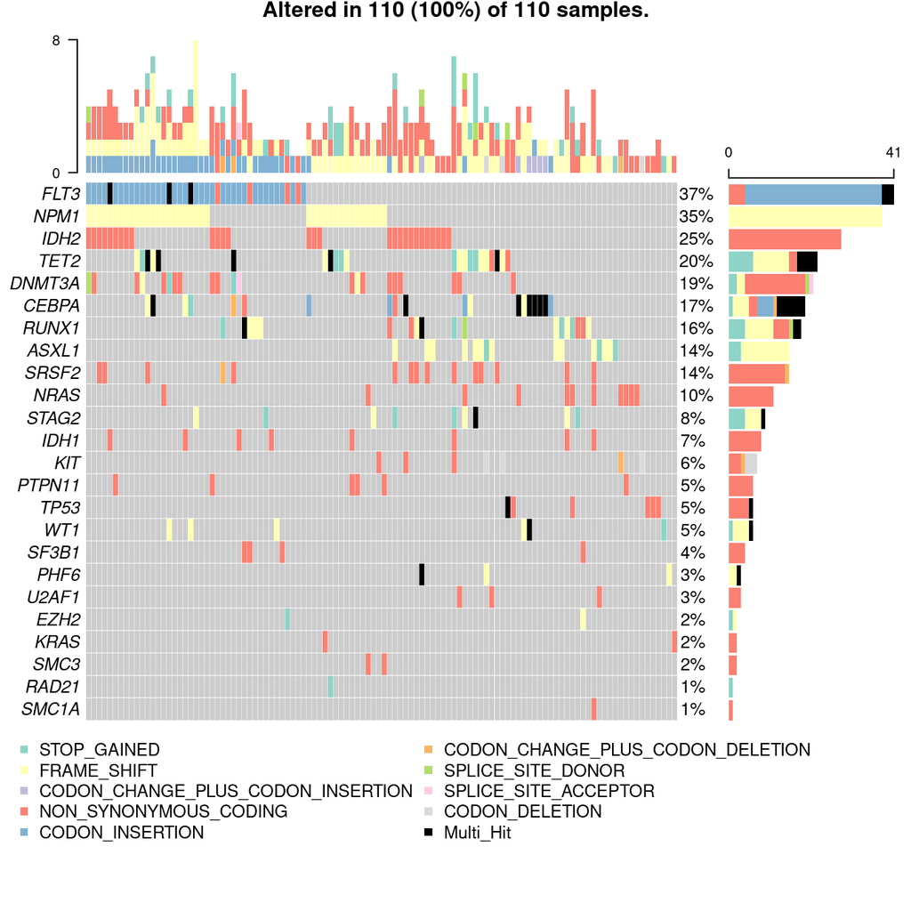

```r
vc_cols <- viridis::viridis_pal()(length(unique(ClinSeq_Curated_mutations_AML$Mutation_Effect))+1)
vc_cols <- c(brewer.pal(n = length(unique(ClinSeq_Curated_mutations_AML$Mutation_Effect)), name = 'Set3'), "#000000")
names(vc_cols) <- c(as.character(unique(ClinSeq_Curated_mutations_AML$Mutation_Effect)), "Multi_Hit")

oncoplot(maf, colors = vc_cols, top = 30)
```

```r
# save(mutations.df, variants.df, file = "~/Projects/AML/data/Mutations/AML_mutations_df.RData")
# save(mut.se, file = "~/Projects/AML/data/Mutations/AML_mut_se.RData")
# save(clinical.info.df, file = "~/Projects/AML/data/Metadata/AML_clinical_metadata_df.RData")
```